# In-class exercise #17: Incumbency Advantage

Do the incumbent politicians have an advantage at the next election? David Lee (2008) collected over 6,000 US house elections results from 1948 to 1998. The idea:

- Democracts win the last election with 50.1% of the vote
- The constituency is (almost) completely indifferent between the two parties
- Is there an advantage for the incumbent Democratic party two years later?

Answer the following question:

1. Is this a sharp or a fuzzy RD? Why?
2. Given the diagnostic plot, run an appropriate model to estimate the incumbency advantage.

The basic design: $VoteShareDiff_{t+1}=\beta_0 + \beta_1 Incumbency_{t} + VoteShareDiff_{t} + u$, where Incumbency = 0 if VoteShareDiff<0, and vice versa.

**Hint: Should your model allow for (a) higher order of polynomials in the running variable? (b) different slopes around the cutoff?**

The dataset is contained in the *rddtools* package, named *house*. There are two variables in the dataset:

- x: vote share difference at election t
- y: vote share difference at election t+1

Your code could start like this:

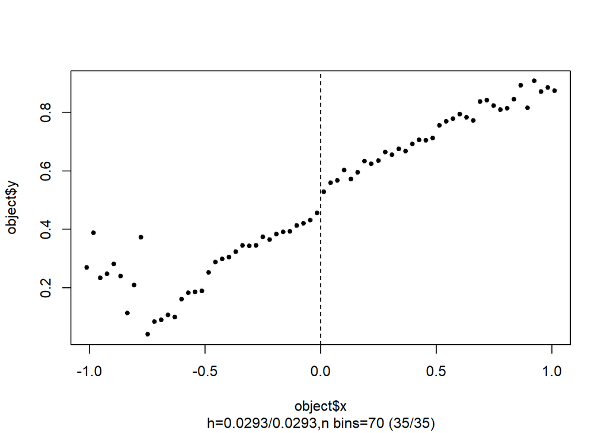

```r
require(rddtools)
data(house)
# here is how to plot the RD design using rddtools
rdd_house <- rdd_data(x=x, y=y, data=house, cutpoint=0)
plot(rdd_house)
```

Answer:

1. This is a sharp RD design. Politician with more votes than their opponent always wins.
2. According to the plot, the best specification seems to be a linear specification with potentially heterogeneous slopes between the two sides of the cutoff. This is essentially a model given as:

$$VS_{t+1}=\beta_0 + \beta_1 D_{t} + \beta_2 (VS_t-D_t) + \beta_3 (VS_t-D_t) * D_t + u$$

This can be implemented as:

```r
library(tidyverse)
library(magrittr)
library(lmtest)
library(sandwich)
house %<>% mutate(incumbent=as.numeric(x>0))
```

```r
lm1 = lm(y~incumbent + x + I(x*incumbent),data=house)
coeftest(lm1,vcov=vcovHC)
```

```
##
## t test of coefficients:
##
##                   Estimate Std. Error t value Pr(>|t|)
## (Intercept)      0.4329479  0.0043350 99.8731  < 2e-16 ***
## incumbent        0.1182314  0.0056225 21.0284  < 2e-16 ***
## x                0.2969065  0.0164040 18.0996  < 2e-16 ***
## I(x * incumbent) 0.0459776  0.0180841  2.5424  0.01103 *
## ---
## Signif. codes:  0 '***' 0.001 '**' 0.01 '*' 0.05 '.' 0.1 ' ' 1
```

This is equivalent to the result estimated by the rddtools package:

```r
rdd_reg_lm(rdd_house,order=1,slope="separate")
```

```
## ### RDD regression: parametric ###
##  Polynomial order:  1
##  Slopes:  separate
##  Number of obs: 6558 (left: 2740, right: 3818)
##
##  Coefficient:
##    Estimate Std. Error t value  Pr(>|t|)
## D 0.1182314  0.0056799  20.816 < 2.2e-16 ***
## ---
## Signif. codes:  0 '***' 0.001 '**' 0.01 '*' 0.05 '.' 0.1 ' ' 1
```

And what does the estimated model look like?

```
## [1] "Mass points detected in the running variable."
```

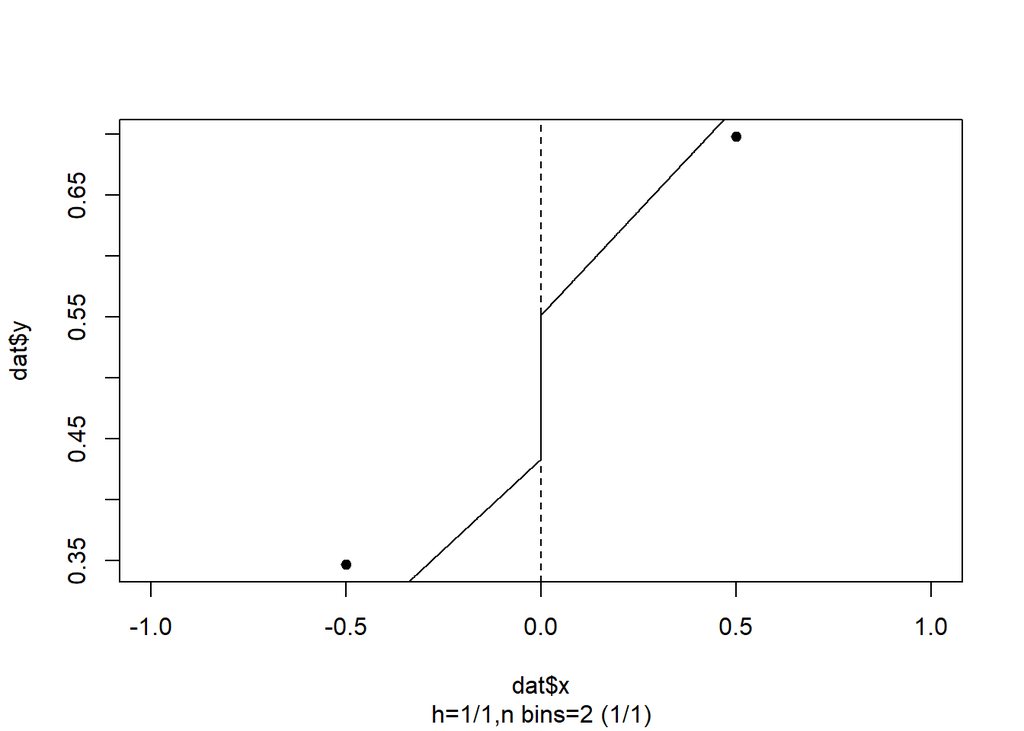

```r
plot(rdd_reg_lm(rdd_house,order=1,slope="separate"))
```